# Lab 2: R Markdown and Basic Objects

Author

Brendan Dishion

External resources used: “How to Use na.omit in R?” (geeksforgeeks)

## A. File paths and Introduction to R Markdown

1. Create a `MATH167R` directory somewhere on your computer that will contain all your work for this class. Within the `MATH167R` folder, create subdirectories for `labs`, `checkins`, and `data`. Save this .Rmd document in your `labs` folder and then Render/Knit your Rmd document. The following code chunk should print the location of your Rmd. document:

```r
getwd()
```

```
[1] "C:/Users/bdish/OneDrive/Documents/Math167R/labs/lab2"
```

2. In the console, run the command `getwd()`. What is the output? If it is different from your answer to Question 1, why? Explain, in your own words, what the working directory is.

My output: “C:/Users/bdish/OneDrive/Documents”

3. Every time you Render/Knit your Rmd document, **all** of the code is run in a **new** R session. Any code run in the interactive session **does not affect** your rendered html file. Create a code chunk below that sets the value of `x` to be your favorite number and then uses `print(x)` to print it out.

```r
x <- 4
print(x)
```

```
[1] 4
```

4. Download [this dataset](https://www.openintro.org/data/csv/cars.csv) to your `data` folder, then use a code chunk with the code `cars <- read.csv("YOUR PATH HERE")` to open the file. You will need to replace the text `YOUR PATH HERE` with the correct location of the dataset to open this successfully.

```r
setwd("C:/Users/bdish/OneDrive/Documents/Math167R/data")
cars <- read.csv("cars.csv")
as.data.frame(cars)
```

```
   speed dist
1      4    2
2      4   10
3      7    4
4      7   22
5      8   16
6      9   10
7     10   18
8     10   26
9     10   34
10    11   17
11    11   28
12    12   14
13    12   20
14    12   24
```

[output cut: 36 more lines]

5. Run the code `head(cars)` in a code chunk to display the first few rows of this dataset.

```r
setwd("C:/Users/bdish/OneDrive/Documents/Math167R/data")
cars <- read.csv("cars.csv")
head(cars)
```

```
  speed dist
1     4    2
2     4   10
3     7    4
4     7   22
5     8   16
6     9   10
```

## B. Vectors and Matrices

6. Write a line of code to generate a vector of length 100 whose entries are 1, 2, …, 100.

```r
vect <- c(1:100)
print(vect)
```

```
  [1]   1   2   3   4   5   6   7   8   9  10  11  12  13  14  15  16  17  18
 [19]  19  20  21  22  23  24  25  26  27  28  29  30  31  32  33  34  35  36
 [37]  37  38  39  40  41  42  43  44  45  46  47  48  49  50  51  52  53  54
 [55]  55  56  57  58  59  60  61  62  63  64  65  66  67  68  69  70  71  72
 [73]  73  74  75  76  77  78  79  80  81  82  83  84  85  86  87  88  89  90
 [91]  91  92  93  94  95  96  97  98  99 100
```

7. Write a line of code to generate the following matrix:

`1 2 3`

`4 5 6`

`7 8 9`

```r
matrx1 <- matrix(1:9, ncol = 3, nrow = 3, byrow = T)
print(matrx1)
```

```
     [,1] [,2] [,3]
[1,]    1    2    3
[2,]    4    5    6
[3,]    7    8    9
```

## C. Working with Data Frames

Use the following code to load the `penguins` data.

```r
# load palmer penguins package
library(palmerpenguins)

# open penguins data as a data frame
data(penguins)
penguins <- as.data.frame(penguins)
```

8. Using the `mean()` function, compute the mean body mass of penguins in the dataset, dropping any missing values.

```r
pen_mass <- mean(penguins$body_mass_g, na.rm = TRUE)
print(pen_mass)
```

```
[1] 4201.754
```

9. Using the `max` function, compute the maximum flipper length of penguins in the dataset, dropping any missing values.

```r
flip_len <- max(penguins$flipper_length_mm, na.rm = TRUE)
print(flip_len)
```

```
[1] 231
```

10. Using the `hist` function, create a histogram of the ratio of the penguins’ bill length to bill depth, dropping any missing values. What is the shape of the resulting distribution?

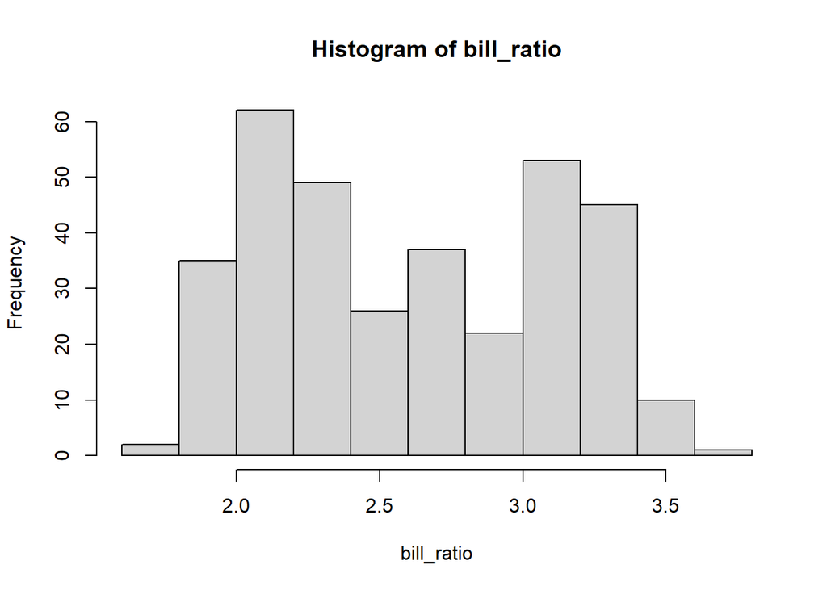

```r
len_clean <- na.omit(penguins$bill_length_mm) #dropping missing values
dep_clean <- na.omit(penguins$bill_depth_mm) #dropping missing values
bill_ratio <- (len_clean / dep_clean)
hist(bill_ratio)
```